# Regression Model for Predicting Water Temperature

##### Importing the requied libraries

```python
import pandas as pd
import numpy as np

import seaborn as sns
import matplotlib.pyplot as plt
from matplotlib.pyplot import figure

from scipy import stats
from sklearn.preprocessing import MinMaxScaler
from sklearn.model_selection import train_test_split
from sklearn.linear_model import LinearRegression

from sklearn.metrics import mean_squared_error
from sklearn.metrics import explained_variance_score
from sklearn.metrics import r2_score
```

### Part A: Data Cleaning & Exploratory Analysis

##### Import full data set using Pandas:

```python
data = pd.read_csv('bottle.csv')
data.head()
```

|  | Cst_Cnt | Btl_Cnt | Sta_ID | Depth_ID | Depthm | T_degC | Salnty | O2ml_L | STheta | O2Sat | ... | R_PHAEO | R_PRES | R_SAMP | DIC1 | DIC2 | TA1 | TA2 | pH2 | pH1 | DIC Quality Comment |
| --- | --- | --- | --- | --- | --- | --- | --- | --- | --- | --- | --- | --- | --- | --- | --- | --- | --- | --- | --- | --- | --- |
| 0 | 1 | 1 | 054.0 056.0 | 19-4903CR-HY-060-0930-05400560-0000A-3 | 0 | 10.50 | 33.440 | NaN | 25.649 | NaN | ... | NaN | 0 | NaN | NaN | NaN | NaN | NaN | NaN | NaN | NaN |
| 1 | 1 | 2 | 054.0 056.0 | 19-4903CR-HY-060-0930-05400560-0008A-3 | 8 | 10.46 | 33.440 | NaN | 25.656 | NaN | ... | NaN | 8 | NaN | NaN | NaN | NaN | NaN | NaN | NaN | NaN |
| 2 | 1 | 3 | 054.0 056.0 | 19-4903CR-HY-060-0930-05400560-0010A-7 | 10 | 10.46 | 33.437 | NaN | 25.654 | NaN | ... | NaN | 10 | NaN | NaN | NaN | NaN | NaN | NaN | NaN | NaN |
| 3 | 1 | 4 | 054.0 056.0 | 19-4903CR-HY-060-0930-05400560-0019A-3 | 19 | 10.45 | 33.420 | NaN | 25.643 | NaN | ... | NaN | 19 | NaN | NaN | NaN | NaN | NaN | NaN | NaN | NaN |
| 4 | 1 | 5 | 054.0 056.0 | 19-4903CR-HY-060-0930-05400560-0020A-7 | 20 | 10.45 | 33.421 | NaN | 25.643 | NaN | ... | NaN | 20 | NaN | NaN | NaN | NaN | NaN | NaN | NaN | NaN |

5 rows × 74 columns

```python
data.shape
```

```
(864863, 74)
```

#### 1 Limit the dataset to the following columns: ['T_degC', 'Salnty', 'STheta','O2ml_L','Depthm']

```python
# Selecting the relevant columns
data = data[['T_degC', 'Salnty', 'STheta','O2ml_L','Depthm']]
data.head()
```

|  | T_degC | Salnty | STheta | O2ml_L | Depthm |
| --- | --- | --- | --- | --- | --- |
| 0 | 10.50 | 33.440 | 25.649 | NaN | 0 |
| 1 | 10.46 | 33.440 | 25.656 | NaN | 8 |
| 2 | 10.46 | 33.437 | 25.654 | NaN | 10 |
| 3 | 10.45 | 33.420 | 25.643 | NaN | 19 |
| 4 | 10.45 | 33.421 | 25.643 | NaN | 20 |

```python
data.shape
```

```
(864863, 5)
```

#### 2 Dropping the NaN and Na and checking the shape of the data

```python
data = data.dropna()
data.shape
```

```
(661268, 5)
```

```python
data.info()
```

```
<class 'pandas.core.frame.DataFrame'>
Int64Index: 661268 entries, 2160 to 864862
Data columns (total 5 columns):
 #   Column  Non-Null Count   Dtype
---  ------  --------------   -----
 0   T_degC  661268 non-null  float64
 1   Salnty  661268 non-null  float64
 2   STheta  661268 non-null  float64
 3   O2ml_L  661268 non-null  float64
 4   Depthm  661268 non-null  int64
dtypes: float64(4), int64(1)
memory usage: 30.3 MB
```

##### Plotting the data

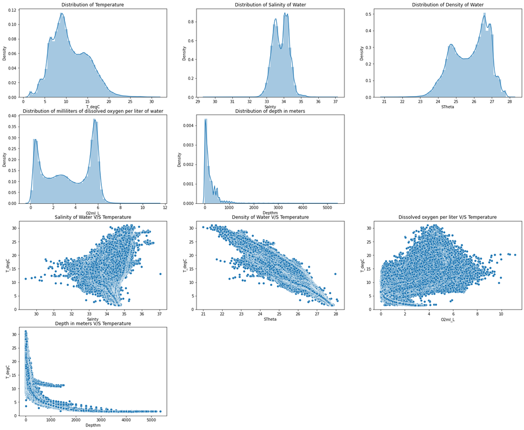

```python
# # Initialise the subplot function using number of rows and columns
plt.figure(figsize=(24,20))

# For T_degC distribution
plt.subplot(4,3,1)
sns.distplot(data['T_degC'])
plt.title('Distribution of Temperature')

# For Salnty (salinity of water)
plt.subplot(4,3,2)
sns.distplot(data['Salnty'])
plt.title('Distribution of Salinity of Water')

# For STheta (density of water)
plt.subplot(4,3,3)
sns.distplot(data['STheta'])
plt.title('Distribution of Density of Water')

# For O2ml_L (milliliters of dissolved oxygen per liter of water)
plt.subplot(4,3,4)
sns.distplot(data['O2ml_L'])
plt.title('Distribution of milliliters of dissolved oxygen per liter of water')

# For Depthm   (depth in meters)
plt.subplot(4,3,5)
sns.distplot(data['Depthm'])
plt.title('Distribution of depth in meters')






# For Salnty (salinity of water) vs T_degC
plt.subplot(4,3,7)
sns.scatterplot(data=data,  x = 'Salnty', y = 'T_degC')
plt.title('Salinity of Water V/S Temperature')

# For STheta (density of water) vs T_degC
plt.subplot(4,3,8)
sns.scatterplot(data=data,  x = 'STheta', y = 'T_degC')
plt.title('Density of Water V/S Temperature')

# For O2ml_L (milliliters of dissolved oxygen per liter of water) vs T_degC
plt.subplot(4,3,9)
sns.scatterplot(data=data,  x = 'O2ml_L', y = 'T_degC')
plt.title('Dissolved oxygen per liter V/S Temperature')

# For Depthm (depth in meters) vs T_degC
plt.subplot(4,3,10)
sns.scatterplot(data=data,  x = 'Depthm', y = 'T_degC')
plt.title('Depth in meters V/S Temperature')
```

Key Take-Aways:

Take Aways from the Scatter Plots:

1. There is some small positive correlation between the Salinity of water and Temperature
2. There is a clear strong negative correlation between the Density of Water and Temperature
3. There is some positive correlation between the Dissolved oxygen per litlre and Temperature
4. There is strong negative correlation between depth and temperature till 500m and then the strength of correlation falls rapidly after 500 m.

#### 3 Remove outliers :

Shape for clean data will be: (661268, 5)

```python
data.shape
```

```
(661268, 5)
```

Outlies have already been removed because of dropping NA's inthe new variables

### Part B: Train & Test Split:

#### 1. Create X & y objects

```python
# Creating the X and Y
X = data.drop(columns = 'T_degC' )
y = data['T_degC']

print("Size of X is: ", X.shape)
print("Size of y is: ", y.shape)
```

```
Size of X is:  (661268, 4)
Size of y is:  (661268,)
```

#### 2 Generate X_train, X_test, y_train & y_test. Use 80% for train & 20% for test.

```python
X_train, X_test, y_train, y_test = train_test_split(X, y, test_size=0.20, random_state=42)

print("Size of X_train is: ", X_train.shape)
print("Size of y_train is: ", y_train.shape)

print("Size of X_test is: ", X_test.shape)
print("Size of y_test is: ", y_test.shape)
```

```
Size of X_train is:  (529014, 4)
Size of y_train is:  (529014,)
Size of X_test is:  (132254, 4)
Size of y_test is:  (132254,)
```

#### 3. Scaling the Data

```python
# Standardizing the variables
scaler = MinMaxScaler()
scaler.fit(X_train)

X_train_scaled = pd.DataFrame(scaler.transform(X_train), columns = X.columns)
X_test_scaled = pd.DataFrame(scaler.transform(X_test), columns = X.columns)
print(X_train_scaled.shape)
print(X_test_scaled.shape)
X_train_scaled.head()
```

```
(529014, 4)
(132254, 4)
```

|  | Salnty | STheta | O2ml_L | Depthm |
| --- | --- | --- | --- | --- |
| 0 | 0.523323 | 0.630450 | 0.457810 | 0.028032 |
| 1 | 0.618318 | 0.802596 | 0.148115 | 0.059428 |
| 2 | 0.496331 | 0.536193 | 0.528725 | 0.005233 |
| 3 | 0.493698 | 0.610090 | 0.605027 | 0.005606 |
| 4 | 0.546122 | 0.405672 | 0.447038 | 0.000000 |

Fitting the scaler on thet train data and using the same scaler to scale the test data.

Y has not been scaled.

### Part C: Using sklearn API

##### 1 Create an instance of the LinearRegression class called "lin_reg". Fit lin_reg using X_train & y_train.

```python
lin_reg = LinearRegression().fit(X_train_scaled, y_train)
```

##### 2 Print out the coefficients (including the intercept)

```python
lin_reg.intercept_
```

```
17.098211226629964
```

```python
lin_reg.coef_
```

```
array([ 27.02294325, -32.52014818,   1.62616582,  -8.15833157])
```

##### 3 Predict T_degC for the test data using the fitted values in b.

```python
y_pred_sklearn = lin_reg.predict(X_test_scaled)
```

##### 4 Calculate the following for the test data:

1. mean squared error
2. r-squared
3. explained variance

```python
mse = round(mean_squared_error(y_test, y_pred_sklearn)*100, 2)
r_square = round(r2_score(y_test, y_pred_sklearn)*100, 2)
explained_var = round(explained_variance_score(y_test, y_pred_sklearn)*100, 2)


print("Mean Squared Error percent is ", mse)
print("R Square is ", r_square)
print("Explained variance ", explained_var)
```

```
Mean Squared Error percent is  11.1
R Square is  99.38
Explained variance  99.38
```

##### 5 Create a scatterplot that shows actual versus predicted values for the T_degC.

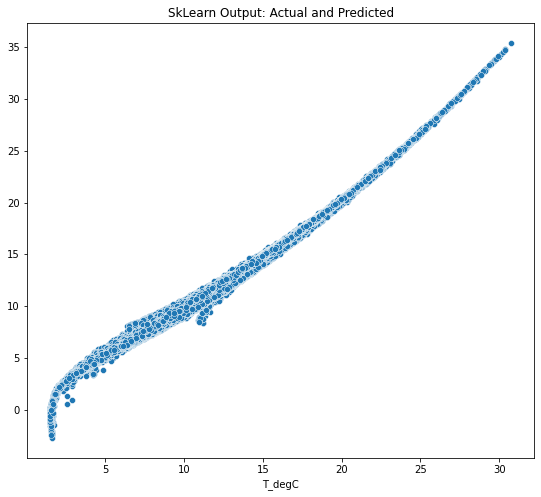

```python
# # Initialise the subplot function using number of rows and columns
plt.figure(figsize=(20,8))

# For SkLearn
plt.subplot(1,2,1)
sns.scatterplot(y_test, y_pred_sklearn)
plt.title('SkLearn Output: Actual and Predicted')
```

### Part D: Gradient Descent Mini-Batch

```python
# Creating a Matrix for the X with the intercept term
X_b = np.c_[np.ones((len(X_train_scaled), 1)), X_train_scaled]
print(X_b.shape)
X_b
```

```
(529014, 5)
```

```
array([[1.        , 0.52332285, 0.63045012, 0.45780969, 0.02803214],
       [1.        , 0.61831761, 0.8025963 , 0.1481149 , 0.05942814],
       [1.        , 0.49633124, 0.53619303, 0.52872531, 0.00523267],
       ...,
       [1.        , 0.51677149, 0.50698462, 0.52154399, 0.00336386],
       [1.        , 0.66837002, 0.88725836, 0.02333932, 0.14950477],
       [1.        , 0.49633124, 0.70396501, 0.51436266, 0.02317324]])
```

```python
# Creating a array for y
y = np.c_[y_train]
print(len(y))
y
```

```
529014
```

```
array([[11.37],
       [ 7.34],
       [13.97],
       ...,
       [15.5 ],
       [ 5.04],
       [ 7.07]])
```

#### Mini-Batch Size = 50

```python
m = len(X_b)

n_iterations = 100
minibatch_size = 50
theta_path_mgd_50 = []

np.random.seed(42)
theta_50 = np.random.randn(5,1)  # random initialization

for epoch in range(n_iterations):
    shuffled_indices = np.random.permutation(m)
    X_b_shuffled = X_b[shuffled_indices]
    y_shuffled = y[shuffled_indices]
    for i in range(0, m, minibatch_size):
        xi = X_b_shuffled[i:i+minibatch_size]
        yi = y_shuffled[i:i+minibatch_size]
        gradients = 2/minibatch_size * xi.T.dot(xi.dot(theta_50) - yi)
        eta = 0.1
        theta_50 = theta_50 - eta * gradients
        theta_path_mgd_50.append(theta_50)
```

```python
m = len(X_b)

n_iterations = 100
minibatch_size = 250
theta_path_mgd_250 = []

np.random.seed(42)
theta_250 = np.random.randn(5,1)  # random initialization

for epoch in range(n_iterations):
    shuffled_indices = np.random.permutation(m)
    X_b_shuffled = X_b[shuffled_indices]
    y_shuffled = y[shuffled_indices]
    for i in range(0, m, minibatch_size):
        xi = X_b_shuffled[i:i+minibatch_size]
        yi = y_shuffled[i:i+minibatch_size]
        gradients = 2/minibatch_size * xi.T.dot(xi.dot(theta_250) - yi)
        eta = 0.1
        theta_250 = theta_250 - eta * gradients
        theta_path_mgd_250.append(theta_250)
```

```python
m = len(X_b)

n_iterations = 100
minibatch_size = 2000
theta_path_mgd_2000 = []

np.random.seed(42)
theta_2000 = np.random.randn(5,1)  # random initialization

for epoch in range(n_iterations):
    shuffled_indices = np.random.permutation(m)
    X_b_shuffled = X_b[shuffled_indices]
    y_shuffled = y[shuffled_indices]
    for i in range(0, m, minibatch_size):
        xi = X_b_shuffled[i:i+minibatch_size]
        yi = y_shuffled[i:i+minibatch_size]
        gradients = 2/minibatch_size * xi.T.dot(xi.dot(theta_2000) - yi)
        eta = 0.1
        theta_2000 = theta_2000 - eta * gradients
        theta_path_mgd_2000.append(theta_2000)
```

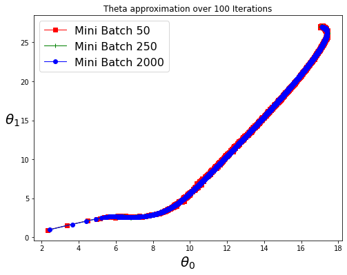

```python
# Plotting the theta approximations for Theta 0 and Theta 1/
theta_path_50 = np.array(theta_path_mgd_50)
theta_path_250 = np.array(theta_path_mgd_250)
theta_path_2000 = np.array(theta_path_mgd_2000)


plt.figure(figsize=(8,6))
plt.plot(theta_path_50[:, 0], theta_path_50[:, 1], "r-s", linewidth=1, label="Mini Batch 50")
plt.plot(theta_path_250[:, 0], theta_path_250[:, 1], "g-+", linewidth=1, label="Mini Batch 250")
plt.plot(theta_path_2000[:, 0], theta_path_2000[:, 1], "b-o", linewidth=1, label="Mini Batch 2000")
plt.legend(loc="upper left", fontsize=16)
plt.xlabel(r"$\theta_0$", fontsize=20)
plt.ylabel(r"$\theta_1$   ", fontsize=20, rotation=0)
plt.title('Theta approximation over 100 Iterations')
plt.show()
```

```python
# Checking the Theta values from the Batch Gradient Descent
theta_summary = pd.DataFrame()
theta_summary['Feature'] = ['Intercept', 'Salnty', 'STheta', 'O2ml_L', 'Depthm']
theta_summary['Mini_Batch_50'] = [item for x in theta_50 for item in x]
theta_summary['Mini_Batch_250'] = [item for x in theta_250 for item in x]
theta_summary['Mini_Batch_2000'] = [item for x in theta_2000 for item in x]
theta_summary['Sklearn'] = np.concatenate(([lin_reg.intercept_] , lin_reg.coef_))
theta_summary
```

|  | Feature | Mini_Batch_50 | Mini_Batch_250 | Mini_Batch_2000 | Sklearn |
| --- | --- | --- | --- | --- | --- |
| 0 | Intercept | 17.123725 | 17.112103 | 17.149607 | 17.098211 |
| 1 | Salnty | 27.036191 | 27.031775 | 26.973145 | 27.022943 |
| 2 | STheta | -32.526778 | -32.519738 | -32.536923 | -32.520148 |
| 3 | O2ml_L | 1.640133 | 1.635881 | 1.602836 | 1.626166 |
| 4 | Depthm | -8.153636 | -8.157098 | -8.140355 | -8.158332 |

```python
# Predicting using the coefficients based on Mini Batch
X_test_new = np.c_[np.ones((len(X_test_scaled), 1)), X_test_scaled]  # add x0 = 1 to each instance

# Mini Batch 50
y_pred_50 = X_test_new.dot(theta_50)
mse_50 = round(mean_squared_error(y_test, y_pred_50)*100, 2)
r_square_50 = round(r2_score(y_test, y_pred_50)*100, 2)
explained_var_50 = round(explained_variance_score(y_test, y_pred_50)*100, 2)

# Mini Batch 250
y_pred_250 = X_test_new.dot(theta_250)
mse_250 = round(mean_squared_error(y_test, y_pred_250)*100, 2)
r_square_250 = round(r2_score(y_test, y_pred_250)*100, 2)
explained_var_250 = round(explained_variance_score(y_test, y_pred_250)*100, 2)

# Mini Batch 2000
y_pred_2000 = X_test_new.dot(theta_2000)
mse_2000 = round(mean_squared_error(y_test, y_pred_2000)*100, 2)
r_square_2000 = round(r2_score(y_test, y_pred_2000)*100, 2)
explained_var_2000 = round(explained_variance_score(y_test, y_pred_2000)*100, 2)
```

```python
# Performance through different batch sizes and Sklearn
perf_metric = pd.DataFrame()
perf_metric['Metric'] = ['Mean Square Error', 'R Square', 'Explained Variance']
perf_metric['Sklearn'] = [mse, r_square, explained_var]
perf_metric['Mini_Batch_50'] = [mse_50, r_square_50, explained_var_50]
perf_metric['Mini_Batch_250'] = [mse_250, r_square_250, explained_var_250]
perf_metric['Mini_Batch_2000'] = [mse_2000, r_square_2000, explained_var_2000]
perf_metric
```

|  | Metric | Sklearn | Mini_Batch_50 | Mini_Batch_250 | Mini_Batch_2000 |
| --- | --- | --- | --- | --- | --- |
| 0 | Mean Square Error | 11.10 | 11.20 | 11.14 | 11.10 |
| 1 | R Square | 99.38 | 99.37 | 99.37 | 99.38 |
| 2 | Explained Variance | 99.38 | 99.38 | 99.38 | 99.38 |

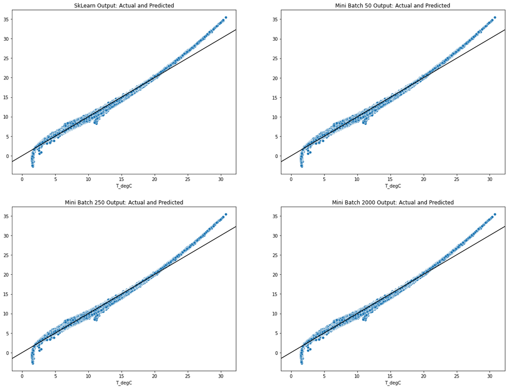

```python
# # Initialise the subplot function using number of rows and columns
plt.figure(figsize=(20,15))

# For SkLearn
plt.subplot(2,2,1)
sns.scatterplot(y_test, y_pred_sklearn)
plt.title('SkLearn Output: Actual and Predicted')
plt.axline([0, 0], [1, 1], color='black')

plt.subplot(2,2,2)
sns.scatterplot(y_test, y_pred_50.flatten())
plt.title('Mini Batch 50 Output: Actual and Predicted')
plt.axline([0, 0], [1, 1], color='black')

plt.subplot(2,2,3)
sns.scatterplot(y_test, y_pred_250.flatten())
plt.title('Mini Batch 250 Output: Actual and Predicted')
plt.axline([0, 0], [1, 1], color='black')

plt.subplot(2,2,4)
sns.scatterplot(y_test, y_pred_2000.flatten())
plt.title('Mini Batch 2000 Output: Actual and Predicted')
plt.axline([0, 0], [1, 1], color='black')
```

### Part E: Conceptual Questions

##### 1) Describe how parameter estimation in Gradient Descent differs from using the normal equation.

Ans.

1. Gradient Descent is an iterative process, it starts with an inital estimate and over each iteration tries to improve it by minimizing the loss function at each iteration. On the other hand Normal equation is an anlytical process. It calculates theta based on solving the equation.
2. Gradient Descent works well with large data on the other hand Normal Equation works well on a small data.
3. Gradient Descent requires a learning rate which is not required in Normal Equation

##### 2) We used Mini-Batch Gradient descent here, but there are a variety of options for Gradient Descent. How is Mini-Batch Gradient Descent different from Stochastic Gradient Descent?

Stochastic Gradient Descent: It uses randomly chosen single instance of data and tries to approximate the theta on each iterations. It is helpful as it helps in jumping out of the local minimum. Since it uses a single instance at each step it is much faster.

Mini Batch Gradient Descent: It instead of selecting a single instance randomly, uses a mini batch of instances randomly and tries to approximate theta on each iteration. Since it uses a mini batch of data thus it is bit slower than Stochastic Gradient Descent but faster than Batch Gradient Descent. On Contrary it has less chances to jump out of local minima in comparison to the Stochastic Gradient Descent.

##### 3) Identify your best-performing version of Gradient Descent and compare the error metrics for test data vs training data. Does this version of gradient descent show signs of overfitting? Explain.

```python
# Fitting Stochastic Gradient Descent
m = len(X_b)
np.random.seed(42)

n_epochs = 100
theta = np.random.randn(5,1)  # random initialization
theta_path_sgd= []

for epoch in range(n_epochs):
    for i in range(m):
        random_index = np.random.randint(m)
        xi = X_b[random_index:random_index+1]
        yi = y[random_index:random_index+1]
        gradients = 2 * xi.T.dot(xi.dot(theta) - yi)
        eta = 0.05
        theta = theta - eta * gradients
        theta_path_sgd.append(theta)
```

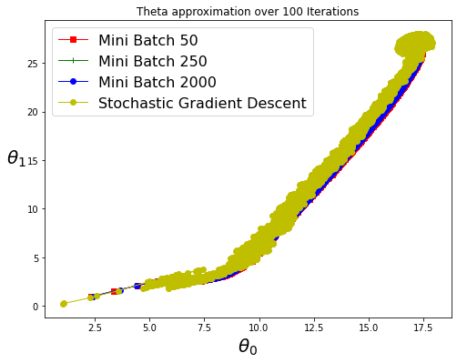

```python
# Plotting the theta approximations for Theta 0 and Theta 1
theta_path_50 = np.array(theta_path_mgd_50)
theta_path_250 = np.array(theta_path_mgd_250)
theta_path_2000 = np.array(theta_path_mgd_2000)
theta_path_sgd = np.array(theta_path_sgd)

import matplotlib as mpl
mpl.rcParams['agg.path.chunksize'] = 10000


plt.figure(figsize=(8,6))
plt.plot(theta_path_50[:, 0], theta_path_50[:, 1], "r-s", linewidth=1, label="Mini Batch 50")
plt.plot(theta_path_250[:, 0], theta_path_250[:, 1], "g-+", linewidth=1, label="Mini Batch 250")
plt.plot(theta_path_2000[:, 0], theta_path_2000[:, 1], "b-o", linewidth=1, label="Mini Batch 2000")
plt.plot(theta_path_sgd[:, 0], theta_path_sgd[:, 1], "y-o", linewidth=1, label="Stochastic Gradient Descent")
plt.legend(loc="upper left", fontsize=16)
plt.xlabel(r"$\theta_0$", fontsize=20)
plt.ylabel(r"$\theta_1$   ", fontsize=20, rotation=0)
plt.title('Theta approximation over 100 Iterations')
plt.show()
```

```python
# Checking the Theta values from the Batch Gradient Descent
theta_summary['Stochastic Gradient Descent'] = [item for x in theta for item in x]
theta_summary
```

|  | Feature | Mini_Batch_50 | Mini_Batch_250 | Mini_Batch_2000 | Sklearn | Stochastic Gradient Descent |
| --- | --- | --- | --- | --- | --- | --- |
| 0 | Intercept | 17.123725 | 17.112103 | 17.149607 | 17.098211 | 17.078089 |
| 1 | Salnty | 27.036191 | 27.031775 | 26.973145 | 27.022943 | 27.245638 |
| 2 | STheta | -32.526778 | -32.519738 | -32.536923 | -32.520148 | -32.516592 |
| 3 | O2ml_L | 1.640133 | 1.635881 | 1.602836 | 1.626166 | 1.742607 |
| 4 | Depthm | -8.153636 | -8.157098 | -8.140355 | -8.158332 | -8.056155 |

```python
## Performance Metrics

# Stochastic GRadient Descent
y_pred_sgd = X_test_new.dot(theta_2000)
mse_sgd = round(mean_squared_error(y_test, y_pred_sgd)*100, 2)
r_square_sgd = round(r2_score(y_test, y_pred_sgd)*100, 2)
explained_var_sgd = round(explained_variance_score(y_test, y_pred_sgd)*100, 2)

perf_metric['Stochastic_Gradient_Descent'] = [mse_sgd, r_square_sgd, explained_var_sgd]
perf_metric
```

|  | Metric | Sklearn | Mini_Batch_50 | Mini_Batch_250 | Mini_Batch_2000 | Stochastic_Gradient_Descent |
| --- | --- | --- | --- | --- | --- | --- |
| 0 | Mean Square Error | 11.10 | 11.20 | 11.14 | 11.10 | 11.10 |
| 1 | R Square | 99.38 | 99.37 | 99.37 | 99.38 | 99.38 |
| 2 | Explained Variance | 99.38 | 99.38 | 99.38 | 99.38 | 99.38 |

```python
# Checking Train and Test Error for Mini Batch and Stochastic Gradient Descent


# Finding the train error
# Stochastic GRadient Descent
y_pred_sgd_train = X_b.dot(theta_2000)
mse_sgd_train = round(mean_squared_error(y, y_pred_sgd_train)*100, 2)
r_square_sgd_train = round(r2_score(y, y_pred_sgd_train)*100, 2)
explained_var_sgd_train = round(explained_variance_score(y, y_pred_sgd_train)*100, 2)


# Mini Batch 2000
y_pred_2000_train = X_b.dot(theta_2000)
mse_2000_train = round(mean_squared_error(y, y_pred_2000_train)*100, 2)
r_square_2000_train = round(r2_score(y, y_pred_2000_train)*100, 2)
explained_var_2000_train = round(explained_variance_score(y, y_pred_2000_train)*100, 2)
```

```python
overfit_check = pd.DataFrame()
overfit_check['Metric'] = ['Mean Square Error', 'R Square', 'Explained Variance']
overfit_check['MiniBatch_2000_Train'] = [mse_2000_train, r_square_2000_train, explained_var_2000_train ]
overfit_check['MiniBatch_2000_Test'] = [mse_2000, r_square_2000, explained_var_2000]

overfit_check['SGD_Train'] = [mse_sgd_train, r_square_sgd_train, explained_var_sgd_train]
overfit_check['SGD_Test'] = [mse_sgd, r_square_sgd, explained_var_sgd]
overfit_check
```

|  | Metric | MiniBatch_2000_Train | MiniBatch_2000_Test | SGD_Train | SGD_Test |
| --- | --- | --- | --- | --- | --- |
| 0 | Mean Square Error | 11.06 | 11.10 | 11.06 | 11.10 |
| 1 | R Square | 99.38 | 99.38 | 99.38 | 99.38 |
| 2 | Explained Variance | 99.38 | 99.38 | 99.38 | 99.38 |

Thus from above we can see that the model is not overfitted as the Train and test performance are quite similar.

##### 4) Explain what the learning rate is for. Even though we did not, why might it be helpful to change the learning rate over time?

Ans. Learning rate basically decides the step size while doing a descent. It is an important parameter as:

1. Small LEarning rate can lead to long training time.
2. Large LEarning Rate can lead to oscillation and thus would fail to converge.

It would be useful to change the learning rate based on the curvature of the gradient:

1. If the curvature is steep then we would want to take small learning rate.
2. If the curvature is small then a large learning rate will help us converge faster.
3. Further initially we would want to have a large learning rate but when we reach at the bottom we would want to have a small learning rate so that we can reach the minima else we would be oscillating at the bottom and would fail to reach the optimum valley bottom.

##### 5) Why would a data scientist want to use early stopping in gradient descent?

Ans. Early stopping is a method to reduce overfitting of the model to the training data. Early stopping can reduce the overfitting and thus reduce the variance of the model.